# Obtaining flow cytometry data

Compiled at 2021-08-19 05:59:10 UTC

```r
## Setup locations
base = "01-cytograms"
here::i_am("01-cytograms.Rmd")
knitr::opts_chunk$set(fig.path = here::here("data", base, 'figures/'))
datadir = outputdir = here::here("data", base)
if(!dir.exists(outputdir)) dir.create(outputdir)
```

# Clean and bin data

Here is a script to do the following; summarizing the workflow: 1. Filter particles from the 3-minute level cytograms (i.e. remove min & max in all three dimensions). 2. Transform fsc_small to diam (Francois explained how to do this to the binned product, but I think it’s cleaner to do the conversion at the particle level, prior to binning). 3. Combine 3-minute level cytograms into hourly cytograms. 4. Bin this data to 40 equally sized bins in each axis (diam, pe, chl). Each bin value would be the sum (not the count) of the Qc of the particles in that bin.

Here are the cruises I want to deal with first:

- KM1508 (SCOPE 3)
- KM1512 (SCOPE 5)
- KM1513 (SCOPE 6)
- KOK1515 (SCOPE 10)
- KM1518 (SCOPE 11)
- KOK1609 (SCOPE 19)

Let me start with this cruise: + Cruise name: SCOPE_3 + Cruise ID: KM1508 + Project: HOT-272

One useful tip (since google drive files are downloaded in separate zip files whenever they’re larger than about 1Gb): + Combine multiple zip files https://stackoverflow.com/questions/60842075/combine-the-split-zip-files-downloading-from-google-drive

# Code for a single cruise

Follow these steps (manual steps for now, but to be streamlined soon!):

1. Upload the `.vct` files (original, particle-level data files) to the server.

```bash
## Uploading directory.
scp -r /media/sangwonh/Backup\ Plus/flowmixapp/data/01-cytograms/SCOPE_3 sangwonh@discovery.usc.edu:repos/flowmixapp/data/01-cytograms/KM1508/orig/.
for cruisename in SCOPE_3 SCOPE_5 SCOPE_6 SCOPE_10 SCOPE_11 SCOPE_19;
do
  ## Figure out how to convert between $cruisename and $cruise_id
  from=/media/sangwonh/Backup\ Plus/flowmixapp/data/01-cytograms/$cruisename
  to=sangwonh@discovery.usc.edu:repos/flowmixapp/data/01-cytograms/$cruise_id/orig/.
  scp $from $to
done
```

using the helper function:

```bash
run (){
    cruise_id=$1
    sbatch  --export=cruise_id=$cruise_id run-bin.slurm
    return 0
}
```

and the binning script `~/scripts/flowmixapp/run-bin.slurm`:

```bash
#!/bin/bash
#SBATCH --ntasks=1
#SBATCH --nodes=1
#SBATCH --mem-per-cpu=10gb
#SBATCH --cpus-per-task=6
#SBATCH --time=1-00:00:00
#SBATCH --export=none  # Ensures job gets a fresh login environment
#SBATCH --mail-user=robohyun66@gmail.com
#SBATCH --mail-type=ALL
#SBATCH --job-name=bin
#SBATCH --output=./logs/%A_%a.log
#SBATCH --error=./logs/%A_%a.err

# Set the session up to use R
module load gcc/8.3.0
module load openblas/0.3.8
module load r/3.6.3

Rscript bin.R \
    mc.cores=6\
    cruise_id=$cruise_id\

exit
```

which in turn calls the script `~/scripts/flowmixapp/bin.R`:

```r
## TODO: copy this script into here.
```

This uses helpers from `~/scripts/flowmixapp/01-helpers.R`. Note, this cytogram data is rescaled so that the diameter is between 0 and 8.

3. The previous step saves the cytograms (along with the covariates `X`, and other things like `lat`, `lon`, and `time`) to an RDS file (e.g. `KM1508-datobj.RDS`), on the server. Download this file from the server to `~/repos/flowmixapp/data/01-cytograms/KM1508/data/.`, using this script:

```bash
# KM1513
for cruise_id in KM1508 KM1512 KM1513 KOK1515 KM1518 KOK1609;
for cruise_id in KM1513;
  do
    from=sangwonh@discovery.usc.edu:repos/flowmixapp/data/01-cytograms/$cruise_id/data/$cruise_id-datobj.RDS
    to=~/repos/flowmixapp/data/01-cytograms/$cruise_id/data/.
  scp $from $to
done
```

# Make plots

We’ll load and plot this cytogram data, in several ways. First, produce 1d plots:

```r
all_cruise_id = c("KM1508", "KM1512", "KM1513", "KOK1515", "KM1518", "KOK1609") ## KM1513 doesn't bin correctly, for now.

for(cruise_id in all_cruise_id){
  cat("### ", cruise_id, "\n")

  ## Load the binned 3d data
  filename = paste0(cruise_id, "-datobj.RDS")
  ybin_obj = readRDS(file = file.path(datadir, cruise_id, "data", filename))
  ylist = ybin_obj$ylist
  qclist = ybin_obj$biomass_list

  ## Make plots of total QC at each time point
  qc_over_time = qclist %>% lapply(sum) %>% unlist()
  p = tibble(time = names(ylist) %>% lubridate::as_datetime(),
         qcsum = as.numeric(qc_over_time)) %>%
    ggplot() +
    geom_line(aes(x = time, y = qcsum), col = rgb(0,0,0,0.2)) +
    geom_point(aes(x = time, y = qcsum), cex = .5) +
    ylab("Sum of QC over time") +
    ggtitle(cruise_id) +
    scale_x_datetime(date_breaks = "6 hour", labels = scales::date_format("%b %d - %H:%M"))
  p = p + theme(axis.text.x = element_text(angle = 25, vjust = 1.0, hjust = 1.0))
  p = p + theme(legend.position="none")
  plot(p)

  ## Make lat/lon plots
  X = ybin_obj$X
  p = X %>% select(time, lat, lon) %>%
    pivot_longer(-one_of("time")) %>%
    ggplot() +
    facet_wrap(~name, scale="free_y", ncol=1) +
    geom_line(aes(x=time, y=value)) +
    scale_x_datetime(date_breaks = "6 hour", labels = scales::date_format("%b %d - %H:%M"))
  p = p + theme(axis.text.x = element_text(angle = 25, vjust = 1.0, hjust = 1.0))
  p = p + theme(legend.position="none")
  plot(p)

  ## Make 1d cytogram plot
  y_qc_list = Map(function(y, qc){ as_tibble(y) %>% add_column(qc = qc) }, ylist, qclist)
  for(dimname in c("diam", "chl", "pe")){

    ## Summarize to 1d binned data
    y_qc_list_1d = y_qc_list %>% purrr::map(. %>% group_by(!!as.name(dimname)) %>% summarise(qc=sum(qc)))
    qclist_1d = y_qc_list_1d %>% purrr::map(.%>% dplyr::pull(qc))
    ylist_1d = y_qc_list_1d %>% purrr::map(.%>% dplyr::pull(!!as.name(dimname)))

    ## Scaling or not?
    for(scale_at_each_time in c(FALSE, TRUE)){
      if(scale_at_each_time) qclist_1d = qclist_1d %>% lapply(function(qc) qc/sum(qc))

      ## Make plots
      mytitle = paste0(cruise_id, " - ", dimname)
      if(scale_at_each_time) mytitle = paste0(mytitle, ", density at each time")
      p = bin_plot_1D(ylist_1d, qclist_1d)
      p = p + ggtitle(mytitle)
      p = p + theme_minimal()
      p = p + scale_x_datetime(date_breaks = "6 hour", labels = scales::date_format("%b %d - %H:%M"))
      p = p + theme(axis.text.x = element_text(angle = 25, vjust = 1.0, hjust = 1.0))
      p = p + theme(legend.position="none")
      plot(p)

      ## Temporary
      ## X %>% select(-id, -lat, -lon) %>%
      ##   pivot_longer(-one_of("time")) %>%
      ##   ggplot() +
      ##   facet_wrap(~name) + ##, scale = "free_y") +
      ##   geom_line(aes(x=time, y=value))

      ## Save to file as well.
      filename = paste0(cruise_id, "-1d-", dimname, ".png")
      if(scale_at_each_time) filename = paste0(cruise_id, "-1d-", dimname, "-density.png")
      ggsave(file = file.path(datadir, cruise_id, "viz", filename),
             width = 10, height = 3, units = "in", dpi = 300, p)
    }
  }
  cat("\n\n")
}
```

### KM1508

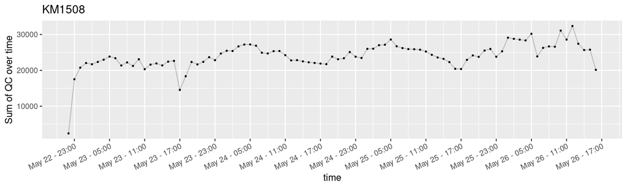

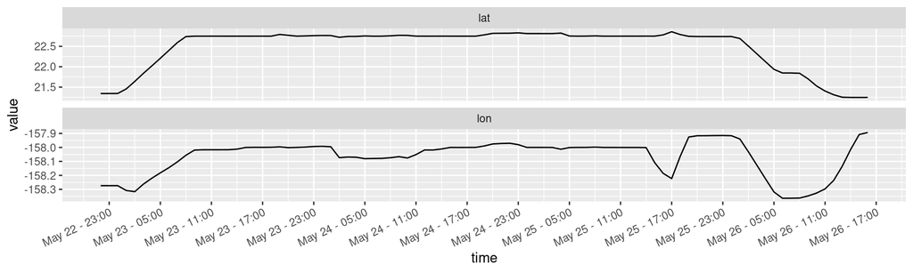

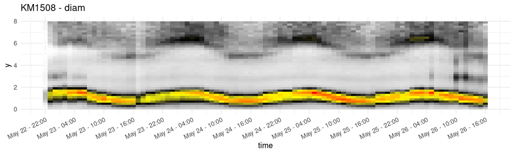

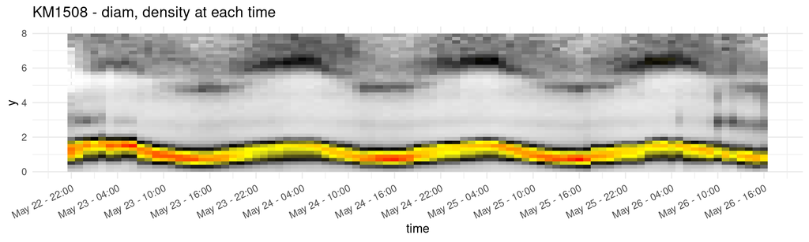

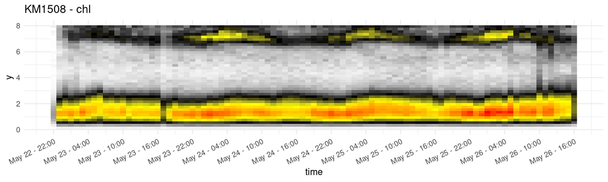

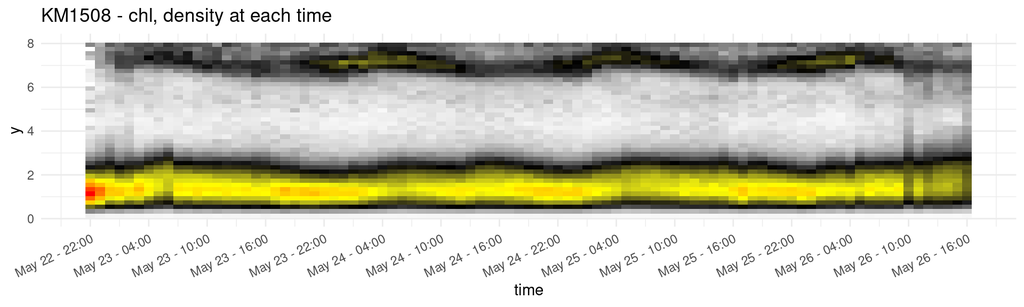

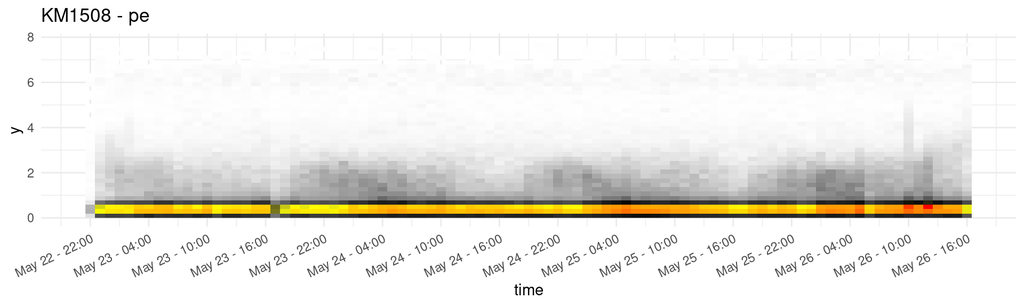

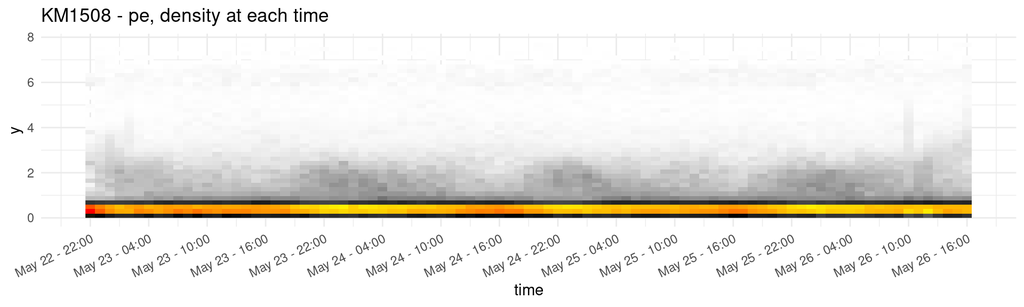

### KM1512

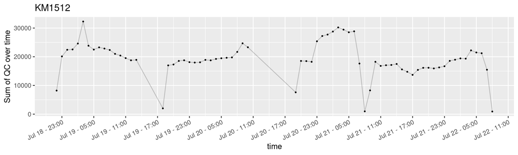

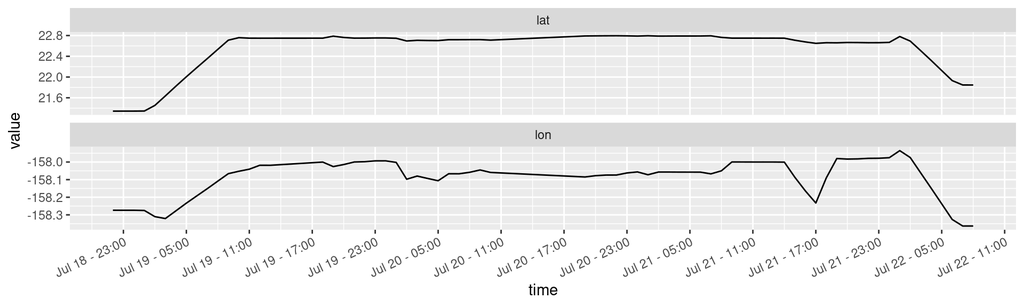

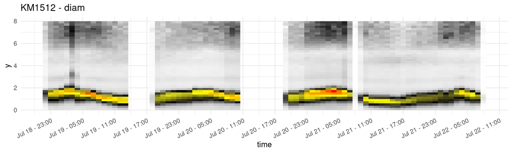

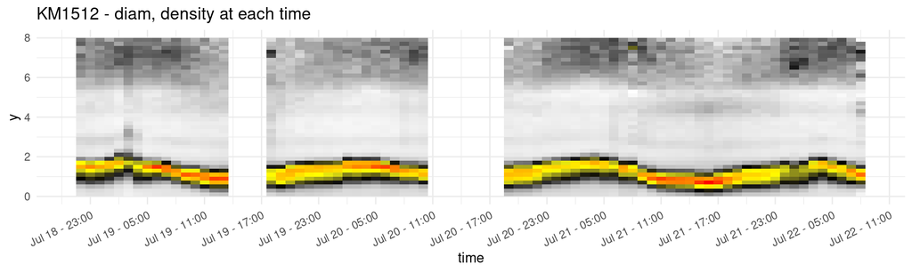

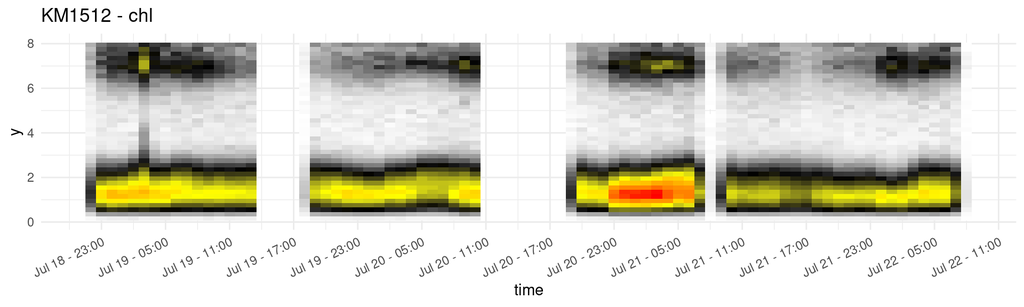

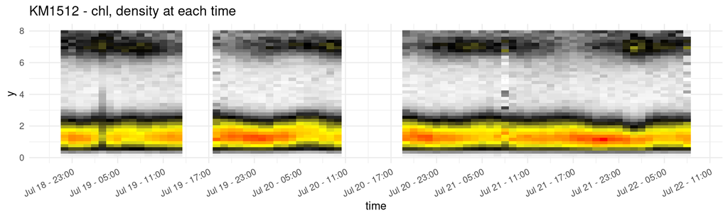

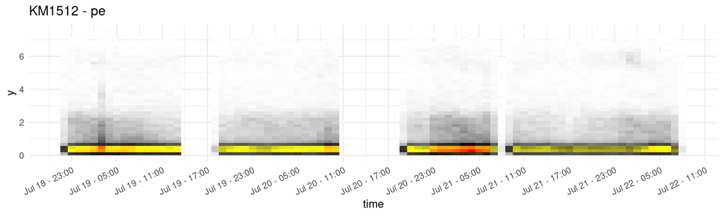

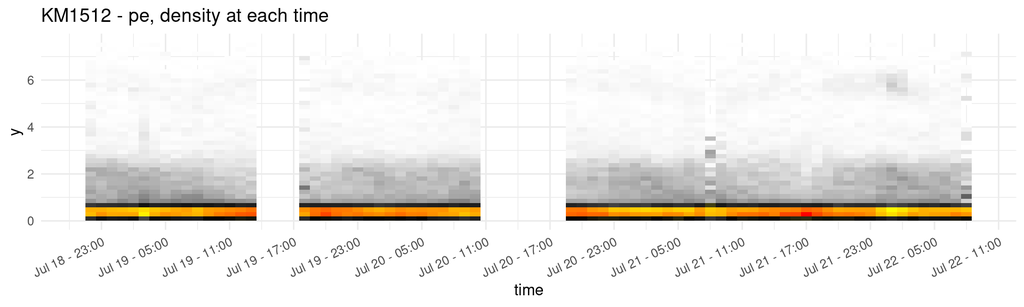

### KM1513

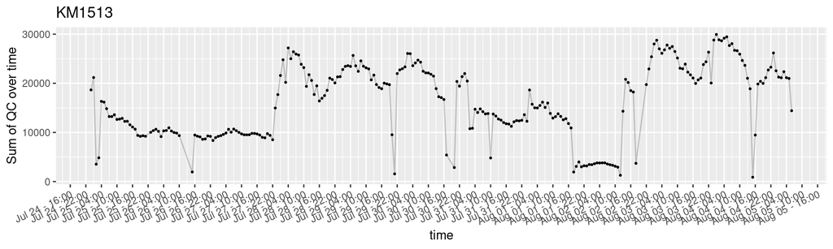

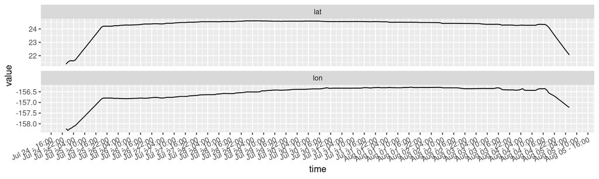

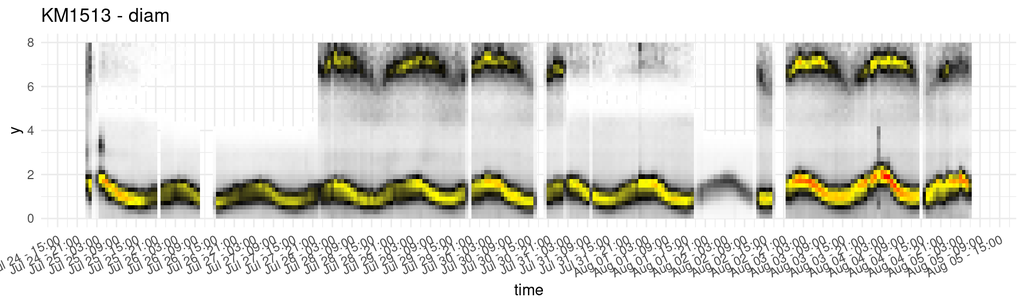

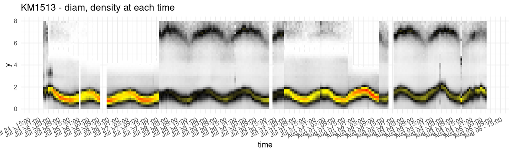

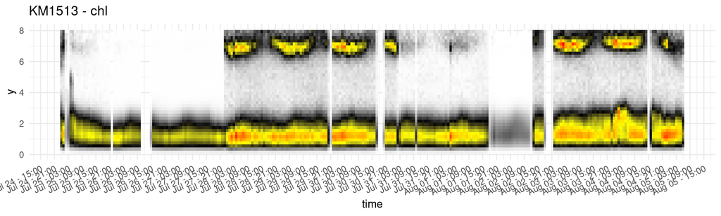

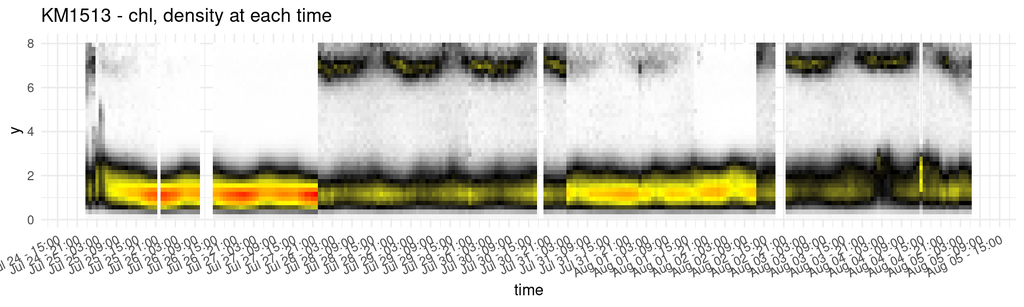

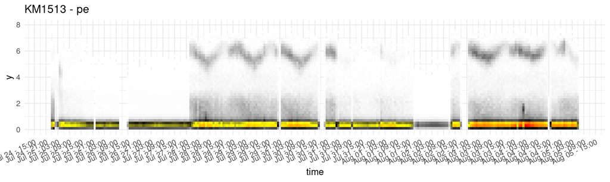

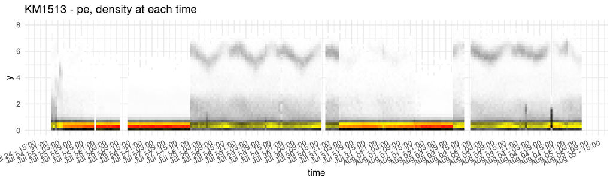

### KOK1515

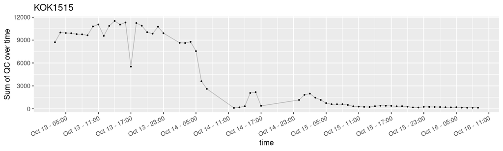

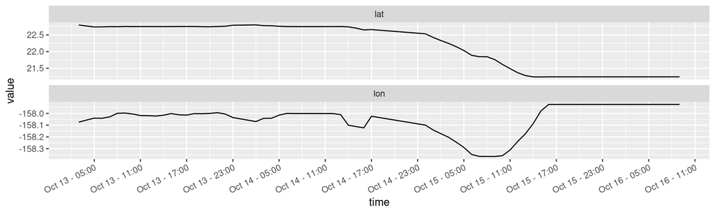

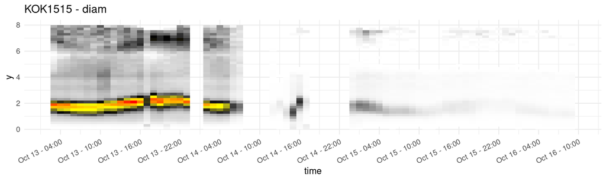

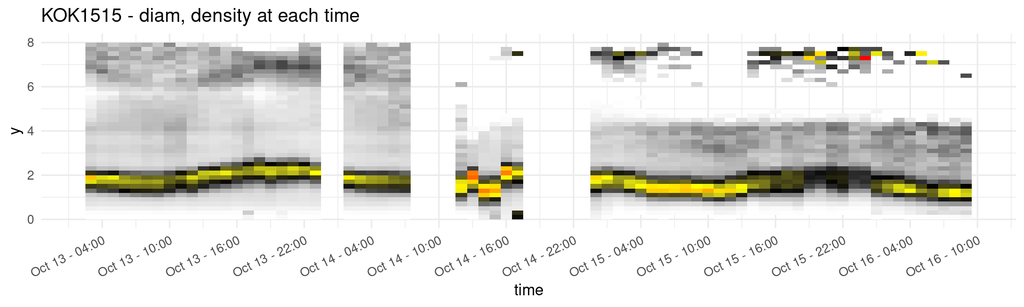

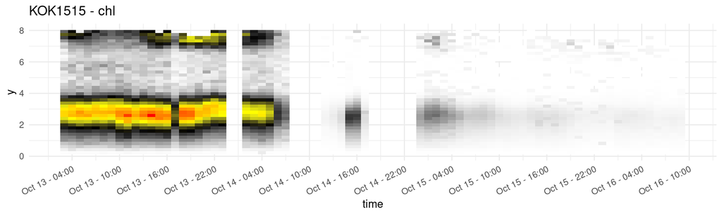

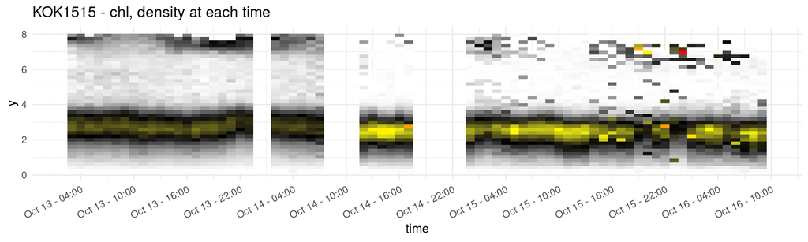

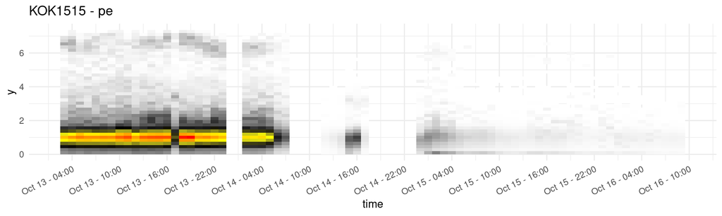

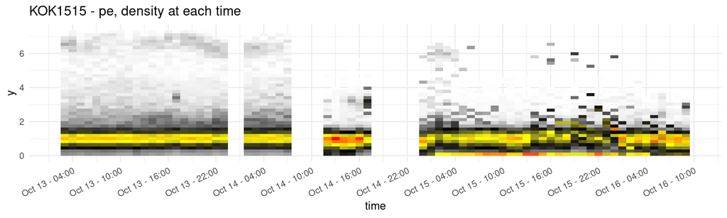